# Accelerating Management Strategy Evaluation Grid-Searches Using Bayesian History Matching, Acquisiton Functions and K-Means Clustering

Author

Emma Bowen

# 1 Abstract

This project introduces a computationally efficient framework for evaluating Harvest Control Rules (HCRs). Initially applied to a single-stock fishery, the framework utilises Gaussian process regression to independently model both catch and risk. Then, by combining the methods of Bayesian history matching, acquisition functions and k-means clustering, we are able to systematically map the sample space. This drastically reduces the need for expensive simulation runs.

Building on this foundation, we scale up this framework to complex mixed-fisheries scenarios. Here, the objective becomes identifying the fishing mortality for each of the interacting stocks that safely maximizes total long-term catch. This framework provides a powerful tool for marine policy by significantly reducing the computational burden of mixed-fishery MSEs whilst ensuring that the stocks remain both economically viable and firmly within safe biological limits. However, there are limitations to our current work which we discuss throughout and summarise when suggesting further developments.

# 2 Introduction

Sustainable fisheries management requires a delicate balance of maximising long-term catch whilst keeping the risk of stock depletion below precautionary thresholds (ICES 2021b). Traditionally, Management Strategy Evaluation (MSE) grid searches are used to find optimal HCRs (Trusts 2016),(ICES 2019a). However, simulating these complex, interconnected dynamics is computationally expensive and time-consuming, particularly as management shifts from single-stock assessments to more realistic, multispecies mixed fisheries (Spence 2025),(Sun et al. 2023),(Pace et al. 2025a).

There has been lots of previous work on this problem. MSEs to test HCRs for single-stock fisheries are a well-established method of fisheries management, being used by ICES to implement single-stock Total Annual Catches (TACs) and thus are widely adopted (ICES 2019a), (Trusts 2019). One of the most recent papers on MSEs for single-stock fisheries uses Gaussian Processes to estimate the results of a simulation, due to the simulation being expensive to evaluate (Spence 2025). This was helped by previous developments in diverse fields (Jones, Schonlau, and Welch 1998),(Huang et al. 2006),(Frazier 2018).

However, for many years researchers have realised that a single-stock approach is not sufficient (Ulrich et al. 2012),(Sun et al. 2023). This has led to a growth in literature relating to how to manage mixed fisheries, including that which we are building on in Section 4 of our report (Ulrich et al. 2012),(Sun et al. 2023),(Pace et al. 2025a). The MSEs for mixed fisheries tend to be more complicated than for single-stock fisheries as they take more factors into account (Ulrich et al. 2012),(Pace et al. 2025a). Thus, finding ways to improve MSE grid searches in a single stock context and then applying this method to mixed fisheries contexts could be beneficial for the fishing industry (Spence 2025),(Pace et al. 2025a),(Hofert and Mächler 2016).

This is our intention throughout this paper. We describe the framework outlined in the abstract in detail with applications to a couple of scenarios, the results of which are discussed in Section 5. We also suggest areas for further development of the method in Section 6.

In the Section 3 part of the project, we build on Spence (2025). This paper is looking to find the HCR parametrised by $F_{target}$ and $B_{trigger}$ that maximises the median long-term catch whilst keeping the risk precautionary for a single-stock fishery (Spence 2025). The paper uses many different methods to achieve this, which we investigate in detail below and apply to our own work. We have focused on enhancing these methods by adding acquisition functions and k-means clustering to improve how we choose to sample points between rounds as this was not deeply considered in the original paper (Spence 2025),(Frazier 2018),(Jones, Schonlau, and Welch 1998),(Huang et al. 2006). We demonstrate clearly how these methods become applicable in our own work in Section 3.3.

# 3 Creating the framework in a single stock fisheries context

## 3.1 Context

We have the objective function Equation 8 in the paper which combines the risk and the catch and so this is the function we want to maximise to get our maximum median long-term catch with the constraint of keeping the risk below 0.05. To do this, the paper takes a Bayesian History Matching (BHM) approach. Firstly, we sample our first eight points which are spaced evenly throughout the sample space to get some initial data. Then, for each round we do the following:

- We set up or update the Gaussian Process (GP) to model $\ln(risk)$ and the GP to model $\ln(median\ catch)$
- We can then use the risk as a threshold so that we only consider the values of $F_{target}$ and $B_{trigger}$ that have a high probability of having risk below 0.05
- We use the GP which is modelling $\ln(median\ catch)$ to get the value for the median catch at every point in the sample space, which will have some uncertainty
- We use BHM to remove any points that are implausible (that have a low probability of being higher than the current best median catch)
- We select 8 plausible points to sample in the next round

We are sampling eight points per round to reduce computation time (Shahriari et al. 2016),(Spence 2025). Now, we will look at the mathematics behind the methods above and also at the acquisition functions which I added to the original code.

## 3.2 General theory

### 3.2.1 Gaussian Processes

A Gaussian Process $F$ has a mean function $\mu_0$ and a covariance function $\operatorname{cov}_0(x_i,x_j)$. We can then evaluate the covariance function $\operatorname{cov}_0(x_i,x_j)$ for every pair $x_i,x_j$ where $i,j\in\{1, ..., n\}$ to find the covariance matrix $\Sigma_{1:n}$ . Then, $F$ is a probability distribution over our objective function $f$ with the property that, for any given collection of points ${x_1,...x_n}$, the marginal probability distribution on $F(x_{1:n}) = (F(x_1),...,F(x_n))$ is given by (Frazier 2018):

$$F(x_{1:n}) \sim N(\mu_0(x_{1:n}),\Sigma_{1:n})
\tag{1}$$

where

$$\mu_0(x_{1:n}) = (\mu_0(x_1), . . ., \mu_0(x_n))$$

We choose a covariance function such that the inputs that have nearby points that have been evaluated have a more certain output than points that are further away from the points that have been evaluated (Spence 2025). This is equivalent to saying that if for some $x,x',x''$ in the design space we have $\|x - x'\| < \|x -x''\|$ for some norm $\| \cdot \|$, then $\operatorname{cov}_0(x, x') > \operatorname{cov}_0(x, x'')$ (Frazier 2018).

We use a GP to emulate the objective function because it is much cheaper to evaluate than our objective function. We can calculate $F(x)$ for any $x$ in the design space as our estimate of $f(x)$ based on our current beliefs. This is true even for the evaluated points $x_1,...,x_m$ as the emulator is fitted to these points (Spence 2025).

### 3.2.2 Maximum Likelihood Estimation

When using GPs to emulate our objective function, we need to be able to estimate the hyperparameters of the GP using the data we gain from evaluating our points $x_1,...,x_n$ (Frazier 2018).

We can do this as follows. Firstly, we let the vector $\eta$ represent the hyperparameters that give us $\mu_0$ and $\operatorname{cov}_0$. Then, given the observations $f(x_{1:n}) = (f(x_1),...,f(x_n))$, we calculate the likelihood of these observations under the prior given $\eta$ which is denoted as $p(f(x_{1:n})|\eta)$ and modelled by Equation 1 . Lastly, we set $\hat{\eta}$ to the value that maximizes this likelihood (Frazier 2018):

$$\hat{\eta} = argmax_\eta p(f(x_{1:n})|\eta)$$

### 3.2.3 Gaussian Process Regression

Gaussian process regression is a Bayesian statistical method for modelling functions (Frazier 2018). Again, let $f$ be the objective function and we focus on the design space $X := \{x_1,...,x_k\}$. Now, if we have evaluated $n$ points such that we have $f(x_{1:n})$ and want to evaluate $x_{n+1}$ we let $k = n+1$ in Equation 1 . Then, we can compute the conditional distribution of $F(x_{n+1})$ given $f(x_{1:n})$ using Bayes’ rule:

$$F(x_{n+1})|f(x_{1:n}) \sim N(\mu_n(x_{n+1}), \sigma^2_n(x_{n+1}))
\tag{2}$$

where:

$$\mu_n(x_{n+1}) = \operatorname{cov}_0(x_{n+1}, x_{1:n})(\Sigma_{1:n})^{-1}(f(x_{1:n}) - \mu_0(x_{1:n})) + \mu_0(x_{n+1})$$

$$\sigma^2_n(x_{n+1}) = \operatorname{cov}_0(x_{n+1},x_{n+1}) - \operatorname{cov}_0(x_{n+1}, x_{1:n})(\Sigma_{1:n})^{-1}\operatorname{cov}_0(x_{1:n},x_{n+1})$$

where:

$$\operatorname{cov}_0(x_{n+1}, x_{1:n}) = (\operatorname{cov}_0(x_{n+1}, x_1), ... , \operatorname{cov}_0(x_{n+1}, x_n))$$

This conditional distribution $F(x_{n+1})|f(x_{1:n})$ is called the posterior probability distribution for $x_{n+1}$. We can calculate this distribution for every point in the design space $X$. This results in a new GP $F_n$ with a mean vector and covariance kernel that depend on the location of the unevaluated points, the locations of the evaluated points $x_{1:n}$, and their values $f(x_{1:n})$ (Frazier 2018). So, we can update our GP every round based on the new points we have evaluated.

### 3.2.4 Bayesian History Matching

Let $x$ be a point in the sample space. We begin with some uncertainty about our objective function $f(x)$ (Spence 2025). However, we can make probabilistic statements such as:

$$P(f(x)>a)= \int_{a}^{\infty}P(f(x))df(x)$$

Once we evaluate another point $x'$ where $x' \neq x$, we are able to use Bayes’ Theorem improve our integral to:

$$P(f(x)>a|f(x'))= \int_{a}^{\infty}P(f(x)|f(x'))df(x)$$

We now let $a=max\{f(x_1),...,f(x_n)\}$ where $n$ is the number of points we have evaluated so far. As the rounds increase we make sure to include all previous points of the objective function that have been evaluated in $n$ (Spence 2025). We remove the point $x$ if:

$$P(f(x)>a|f(x_{1:n})) = \int_{a}^{\infty}P(f(x)|f(x_{1:n}))df(x) <\varepsilon
\tag{3}$$

for a small $\varepsilon > 0$ until no plausible points remain. Then, the optimum will be $x^*$ such that:

$$f(x^*) = max\{f(x_{1:n})\}$$

as our index $n$ counts the number of points we have evaluated throughout the whole simulation.

### 3.2.5 Expected Improvement

The first type of acquisition function we will look at is Expected Improvement (EI). Suppose we have sampled the points $x_1, ... ,x_n$ and observe the values $f(x_{1:n})$. Then, if we were to return a solution at this point, bearing in mind we observe the objective function $f$ without noise and we can only return points we have already evaluated, we would return $f^*_n = max\{f(x_1),...,f(x_n)\}$ (Frazier 2018). Imagine we then consider evaluating another point $x_{n+1}$ to get $f(x_{n+1})$. We can then define the Expected Improvement as:

$$EI_n(x_{n+1}) := E[F(x_{n+1})|f(x_{1:n})-f^*_n]^+$$

where $[F(x_{n+1})-f^*_n]^+$ is the positive part of $[F(x_{n+1})-f^*_n]$. This acquisition function is relatively easy to optimise and many different methods have been developed for doing this (Frazier 2018).

There is another expression for $EI_n(x_{n+1})$:

$$EI_n(x_{n+1}) = [(\mu_n(x_{n+1})-f_n^*\cdot\Phi(Z))+(\sigma_n(x_{n+1})\cdot\phi(Z))]^+
\tag{4}$$

where again the notation $[\cdot]^+$ means the positive part and where:

$$Z = \frac{\mu_n(x_{n+1})-f_n^*}{\sigma_n(x_{n+1})}$$

Equation 4 can be gained from Equation 1 by setting $k = n+1$ and then studying the distribution of $F(x_{n+1})-f^*_n$. However, we can also consider it as a version of Equation 15 from Jones, Schonlau, and Welch (1998) where we first flip the signs as we are focused on the maximisation case and then set $f_{min} = f^*_n$, $\hat{y} = \mu_n(x)$ and $s = \sigma_n(x)$.

### 3.2.6 Augmented Expected Improvement

This was included to help make the method perform better for noisy functions which will make it more generally applicable (Huang et al. 2006). To deal with these noisy observations, a change was proposed to the standard EI function as detailed below. This change seems mostly to have been justified by empirical performance (Letham et al. 2018). By adjusting Equation 12 found in Huang et al. (2006) to our own notation, we get that:

$$AEI_n(x_{n+1})=E[F(x_{n+1})|f(x_{1:n})-f^*_{eb}]^+\Biggl(1- \frac{\sigma_{obs}}{\sqrt{\sigma_n^2(x_{n+1})+\sigma_{obs}^2}}\Biggr)$$

where $\sigma_{obs}$ is the standard deviation of the noise variable set by the user and $\sigma_n(x)$ is the standard deviation of GP $F$ at the $n^{th}$ iteration, as used beforehand. We have also changed $f^*_n$ to $f^*_{eb}$ which is the highest predicted mean at any sampled point so far so that we take into account that the uncertainty in our observations could cause a large spike (Huang et al. 2006).

### 3.2.7 Knowledge Gradient

We remove the assumption of EI that we have to return a pre-evaluated point as our best point (Frazier 2018). We also now start by saying that the solution we would choose if we have to stop sampling after $n$ points would be the point in the design space with the largest $\mu_n(\cdot)$ value, where $\mu_n(\cdot)$ is the mean vector of the posterior probability distribution after $n$ iterations. We call this maximum ${x_n^*}$ and then we can say that $F(x_n^*)$ is random under the posterior distribution and has the mean vector after sampling $f(x_{1:n})$ of:

$$\mu_n^* := \mu_n(x_n^*) = max_{x}\mu_n(x)$$

where $x$ is any point in the sample space (Frazier 2018). Then, we imagine that we are now allowed to sample a new point $x_{n+1}$. We get a new posterior distribution at the point $x$ which we can calculate using Equation 2 by replacing $x_{n+1}$ with $x$ and $x_{1:n}$ with $x_{1:n+1}$ to include our new observation. This will have the posterior mean function $\mu_{n+1}(\cdot)$ defined as:

$$\mu_{n+1}(x) = \mu_n(x) + \frac{\operatorname{cov}_n(x_{n+1},x)}{\operatorname{var}_n(x_{n+1}) + \sigma_{\mathrm{obs}}^2}(F(x_{n+1})|f(x_{1:n})-\mu_n(x_{n+1}))
\tag{5}$$

where $\sigma_{obs}$ is a noise variable which can be determined by the user (Ungredda, Pearce, and Branke 2022). The conditional expected value for $F(x_n^*)$ changes to be:

$$\mu_{n+1}^* := max_x\mu_{n+1}(x)$$

So, we can see that the increase in the conditional expected value of $F(x_n^*)$ by sampling the new point $x_{n+1}$ is:

$$\mu_{n+1}^* - \mu_n^*
\tag{6}$$

While this quantity is unknown before we sample $x_{n+1}$, we can calculate it’s expected value given our observations $x_1,...,x_n$. The Knowledge Gradient (KG) for sampling at a new point $x$ in the design space is defined as (Frazier 2018):

$$KG_n(x) := E[\mu_{n+1}^* - \mu_n^*|x_{n+1} = x]
\tag{7}$$

The easiest way to calculate the KG is via simulation. This can be done by simulating one possible value for $f(x_{n+1})$ and then calculating Equation 6. We iterate this process many times so that we can find the average of $\mu_{n+1}^* - \mu_n^*$ and this allows us to estimate $KG_n(x)$ (Frazier 2018). This process, or calculating $KG_n(x)$ directly from the properties of the normal distribution, both work well in discrete, low dimensional problems which is the situation we are in for the first half of the project (Frazier 2018). We would sample the point $x$ with the largest $KG_n(x)$ as our next point (Frazier 2018).

### 3.2.8 K-means process for selecting multiple points

Combining a clustering method with an acquisition function was an idea I had early on in the project. I was then able to find literature on the subject, including using k-means clustering.

Let us have a design space $X$ as before. We want to be able to select multiple points to sample in our next round so that we continue the pattern set up in the original paper, whilst keeping a good trade off between exploration and exploitation (Spence 2025),(Azimi, Fern, and Fern 2010). So, we use the k-means clustering method, which is the most commonly used due to its simplicity compared to other clustering algorithms (Kodinariya, Makwana, et al. 2013).

This algorithm creates $k$ clusters (groups of points) such that the points within each cluster have the sum of squares to the centre of their cluster smaller than it would be to the centre of any other cluster (RDocumentation 2025). It starts by defining $k$ centroids which should be placed as much as possible far away from each other (Kodinariya, Makwana, et al. 2013). Then, we take each point in the space and associate it to the nearest centroid. We stop when every point has been assigned to a centroid (Kodinariya, Makwana, et al. 2013). At this point, we re-calculate $k$ new centroids as the centers of the clusters created by the previous step. This may result in some points changing clusters (Hartigan and Wong 1979). We repeat this process until no points change clusters (Hartigan and Wong 1979),(Kodinariya, Makwana, et al. 2013).

However, before the algorithm can start, we must specify how many clusters we want (Kodinariya, Makwana, et al. 2013). This can be difficult in many cases (Kodinariya, Makwana, et al. 2013). In our case, it is relatively simple as we know how many points we want to sample next and so we set this to be the number of clusters. Lastly, we run the algorithm on $X$ to form the clusters and then we pick the point with the highest value of the acquisition function from each cluster to sample in our next round.

## 3.3 Application of theory in this half of my project

### 3.3.1 Set up the Gaussian Processes

We are focusing on maximising the objective function from the paper which is given below (Spence 2025):

$$f(\theta) = I_{[0.95,1]}(P(B(\theta)>B_{lim})) \times C(\theta)
\tag{8}$$

where $C(\theta)$ is median long term catch, $B(\theta)$ is long-term $SSB$ and:

$$I_{[0.95,1]}(x) =
\begin{cases}
1 & \text{if } x\in[0.95,1] \\
0 & \text{otherwise }
\end{cases}$$

is an indicator function.

To do this, Spence (2025) uses two GPs where the risk GP models $\ln(risk)$ and the catch GP models $\ln(median\ catch)$ (Spence 2025). Maintaining the notation from Spence (2025), we use $m_1$ for the mean function of the catch GP and $m_2$ for the mean function of the risk GP (Spence 2025):

$$\begin{split}
m_1 (\phi) = \beta_{1,0} + \beta_{1,1} (\operatorname{ln}(\phi_1 + 0.1))+\beta_{1,2}(\operatorname{ln}(\phi_1 + 0.1))^2 + \\
\beta_{1,3}(\operatorname{ln}(\phi_1 + 0.1))^3+ \beta_{1,4}(\phi_2\operatorname{ln}(\phi_1 + 0.1)) + \beta_{1,5}\phi_2
\end{split}
\tag{9}$$

$$m_2(\phi) = \beta_{2,0} + \beta_{2,1}\phi_1 + \beta_{2,2}\phi_2 + \beta_{2,3}\phi_1\phi_2
\tag{10}$$

where all of the above $\beta_{s,t}$ for $s \in \{1,2\}$ and $t \in \{1,2,3,4,5\}$ are coefficients to be found through maximum likelihood estimation and:

$$\phi_1 = \frac{F_{target}-0.1}{0.4} \quad \textrm{and} \quad \phi_2 = \frac{B_{trigger}-110000}{90000}$$

as we have rescaled for numerical stability in the GP (Spence 2025). Our covariance function $c$ for both GPs is the variance $\sigma_i^2$ (which is acting as a scalar) times the Ornstein-Uhlenbeck correlation function (Spence 2025):

$$r_i(\phi,\phi',\delta_i) = \operatorname{exp} \left(-\frac{|\phi_1 - \phi'_1|}{\delta_{i,1}} - \frac{|\phi_2 - \phi_2'|}{\delta_{i,2}}\right)
\tag{11}$$

where ${\delta_{i,1}}$ and ${\delta_{i,2}}$ are the length scales for each of the terms respectively (Williams and Rasmussen 2006).

We need to sample our first round of eight points before setting up the GPs so that we have enough data to estimate all of the coefficients in our GPs (Jones, Schonlau, and Welch 1998). Note that until we have sampled sixteen points, we set the prior of the catch GP to be the same as the risk GP, $m_2(\phi)$, except with different coefficients (Spence 2025). This is because we need to estimate the coefficients for the mean function for the catch GP and the length scales for the covariance function $c$ from the same data (Jones, Schonlau, and Welch 1998),(Roustant, Ginsbourger, and Deville 2012a).

For mathematical stability, these functions should have less than eight coefficients between them in our first round as we are only sampling eight points per round due to computational limitations encountered at the time of the Spence 2025 paper (Jones, Schonlau, and Welch 1998),(Spence 2025). However, after our first round we reset the mean function for the catch GP to $m_1(\phi)$ (Spence 2025).

We can set up Gaussian Processes (GPs) as described above in R using the DiceKriging package and use maximum likelihood estimation to get the hyperparameters of $m_1(\phi),m_2(\phi)$ and $c$ for our GPs (Roustant 2025),(Roustant, Ginsbourger, and Deville 2012a). Then, we use them to predict the $\ln(median\ catch)$ and $\ln(risk)$ at every point in the design space. We can then exponentiate these results where needed. We are building our GPs with $\ln$ of the values we want because this helps us generate better predictions (Huang et al. 2006). We have also been able to visualise these GPs in some of the code linked in Section 7.

### 3.3.2 Excluding implausible points

Recall from Section 3.3.1 that we have the GP for $\ln(median\ catch)$ which is modeling the $C(\theta)$ part of the objective function. As the first half of the objective function $f$ is an indicator function, we can focus on maximising $C(\theta)$ whilst meeting the threshold stated by the indicator function (Frazier 2018),(Jones, Schonlau, and Welch 1998).

Firstly, we enforce the threshold in the indicator function by calculating $P(\ln(risk)\le\ln(0.05))$, which is equivalent to the precautionary threshold $P(risk\le0.05)$. We calculate this by making predictions for $\ln(risk)$ at each point using our risk GP and finding the probability that these predictions are below $\ln(0.05)$. This probability can be found using Equation 2. Then, we exclude any points with $P(\ln(risk)\le \ln(0.05))\le\ \varepsilon = 0.0001$ by setting their value for the acquisition function equal to $0$. This means they will not be chosen as a point to sample in the next round.

To maximise $C(\theta)$, we use Bayesian history matching to speed up the process by removing any points that are implausible when $a$ is median catch according to Equation 3.

This full process ensures that only points that meet the precautionary threshold and and are plausible according to Equation 3 can be selected.

### 3.3.3 Deciding on the next point to sample

We have three different acquisition functions we have investigated using here. We set the value for each acquisition function to zero if the point doesn’t meet the precautionary threshold.

For Expected Improvement, we use the Equation 4 expression and calculate the EI for every point in the sample space. For Augmented Expected Improvement, as our situation has no noise, in our code we are still using $f^*_n$ (Spence 2025),(Frazier 2018),(Huang et al. 2006). Thus, we use the equation:

$$AEI_n(x_{n+1})=EI_n(x_{n+1})\Biggl(1- \frac{\sigma_{obs}}{\sqrt{\sigma_n^2(x_{n+1})+\sigma_{obs}^2}}\Biggr)$$

to calculate the AEI for every point in the sample space, where we set $\sigma_{obs} = 0$. For Knowledge Gradient, we estimate the KG from 100 simulations and update the KG each round using Equation 5 .

We have now been able to determine which points are possible based on the probability that their median catch is higher than the current maximum median catch (using BHM) and the probability that their risk is less than 0.05. These points will be called the Possible Space, $PS$. We have then assigned a value to each point in $PS$ using one of the acquisition functions above. Now, we want to decide which 8 points are best to evaluate next.

We use the `kmeans` function which is part of the stats package in R to do this. This function uses the algorithm from Hartigan and Wong (1979) by default and implements our k-means algorithm described in the General Theory section (RDocumentation 2025). We set $k=8$ to create eight clusters so that we select eight points to sample next round. This method allows us to search for viable points by looking in the $PS$ but also to keep the points we are going to sample spread out so that we can balance exploitation and exploration more effectively (Azimi, Fern, and Fern 2010).

### 3.3.4 Updating our GPS

In our second round, we need to update our GPs with new data (Spence 2025). We do this by adding in the data for the points that have been newly evaluated this round. Hence, we can do the calculations from Section 3.2.3 to update the GP with a new mean vector and covariance kernel for our next round.

Now, we repeat the full process described in the Application of theory in this half of my project section until there are no points with an acquisition function value greater than zero. Then, the optimal point is the $x^*$ that has the highest median catch. In our case, $x^*$ is the $F_{target}$ and $B_{trigger}$ that will give the highest median long-term catch whilst following the precautionary principle (Spence 2025).

## 3.4 Experimenting with the kernel and mean

Along with my project supervisor, I decided to run some experiments determining whether changing the kernel and mean used in the Case Study in Spence (2025) would have an effect on the value determined as the optimal point. This was due to the fact that the exponential kernel, also called the Ornstein–Uhlenbeck correlation function, being used in the Case Study (Equation 11) is not as smooth as the Gaussian kernel (general form shown in Equation 12). This was questioned by my supervisor as the Gaussian kernel is more widely used (Williams and Rasmussen 2006).

$$r(\phi) = \textrm{exp}\left(-\frac{r^2}{2l^2}\right)
\tag{12}$$

The mean was also identified as a possible issue. By assuming a very specific mean (shown in Equation 9 or Equation 10) for the GP we are assuming that we know a lot about the objective function $f$ (Williams and Rasmussen 2006). Thus, it was suggested that I try using a zero mean which is commonly done when we do not want to make any assumptions about our objective function (Williams and Rasmussen 2006).

### 3.4.1 Experimenting with the kernel

The assumption made by the Gaussian kernel of infinite differentiability can be too strong for real-world processes as it is very smooth (Williams and Rasmussen 2006). The GP will create a very smooth surface due to the very smooth assumption in the Gaussian kernel (Williams and Rasmussen 2006). If a new point we sample does not fit this assumption, then the GP is unsure how to proceed and so sets the variance very high as if it knew nothing, sometimes called a variance explosion (Williams and Rasmussen 2006). This results in many points that had been deemed implausible returning to the Possible Space and this is likely to continue unless different sampling points are chosen (Williams and Rasmussen 2006). It is instead recommended that we use a kernel from the Matern class of kernels, which includes the exponential kernel (Williams and Rasmussen 2006).

My experiments appear to back up this theory. Using the exponential kernel, the GP converges to a solution after seven rounds. After changing the kernel to be the Gaussian kernel or the Matern kernel with $\nu = \frac{5}{2}$ it can be seen that neither of these alternatives converge after seven rounds. In each heatmap below, we are plotting how likely the model thinks it is that this point will be a solution with a higher median catch, but still precautionary. Any areas with:

$$P(catch<current\ best\ catch)<0.0001\ \textrm{or}\ P(risk \le 0.05)<0.0001$$

have been ruled out as implausible and are displayed as dark blue.

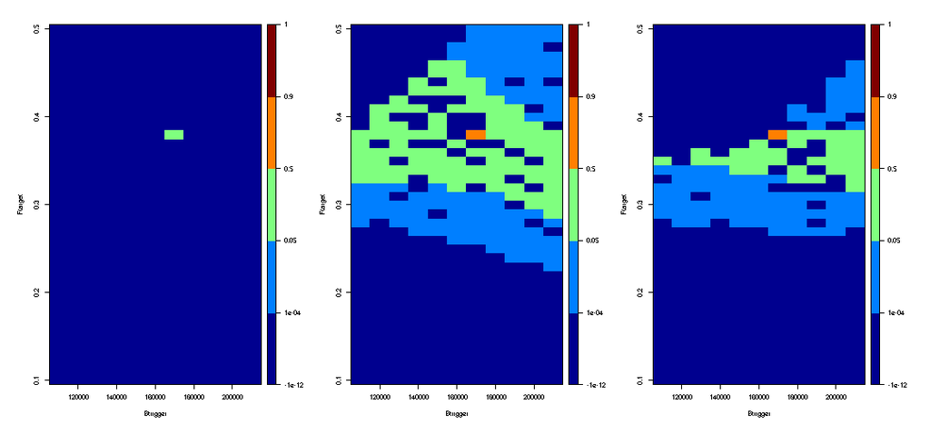

Figure 1: Comparison of convergence under different kernels in the seventh round in case_study8. From left to right: the Exponential kernel, the Gaussian kernel and the Matern 5/2 kernel.

Similar results occur when we run the method once it has been augmented by an acquisition function. As we then allow the method to continue until it has converged, we find that the different kernels cause convergence in a different number of rounds. For example, the EI method converges after seven rounds with the exponential kernel, but after changing to the Gauss kernel it converges after twenty five rounds. When using the Matern 5/2 kernel, the GP does not converge to the correct point.

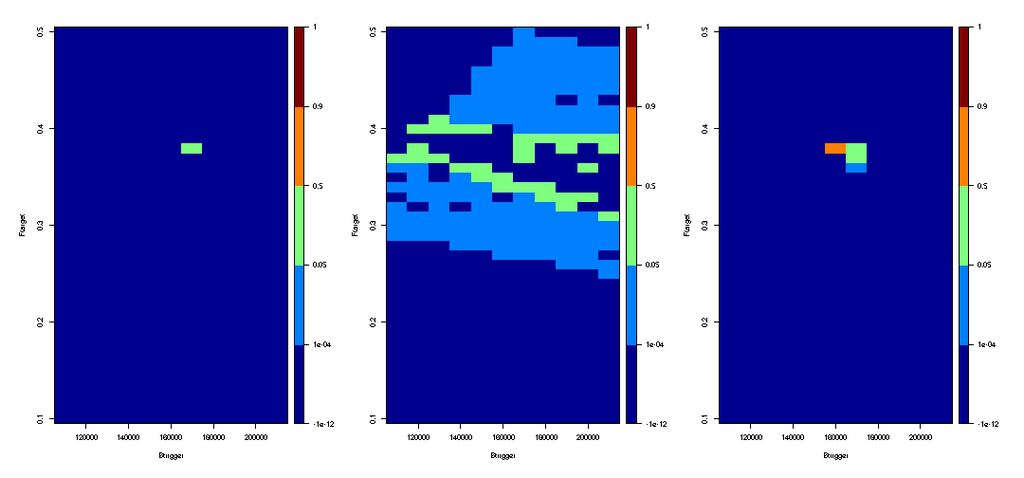

Figure 2: Comparison of convergence under different kernels in case_study8 augmented with the EI acquisition function. From left to right: the Exponential kernel, the Gaussian kernel in the seventh round and the Matern 5/2 kernel in the last round.

### 3.4.2 Experimenting with the mean

Setting the mean of the GP to zero is more often done in examples to showcase the key concepts than when implementing these methods in real-world situations (Williams and Rasmussen 2006). My experiments seem to back up this theory as they again show that results are the same or worse than our original approach.

We can see from the heatmaps below that the simulations with means changed to zero either converge at the same round or later on than when we use the original mean specified in (Spence 2025). This is likely to be because we are able to encode information that we already know about how fisheries and stocks operate when using the original mean, which helps the GP to narrow down to the optimal point in less rounds (Spence 2025), (Williams and Rasmussen 2006).

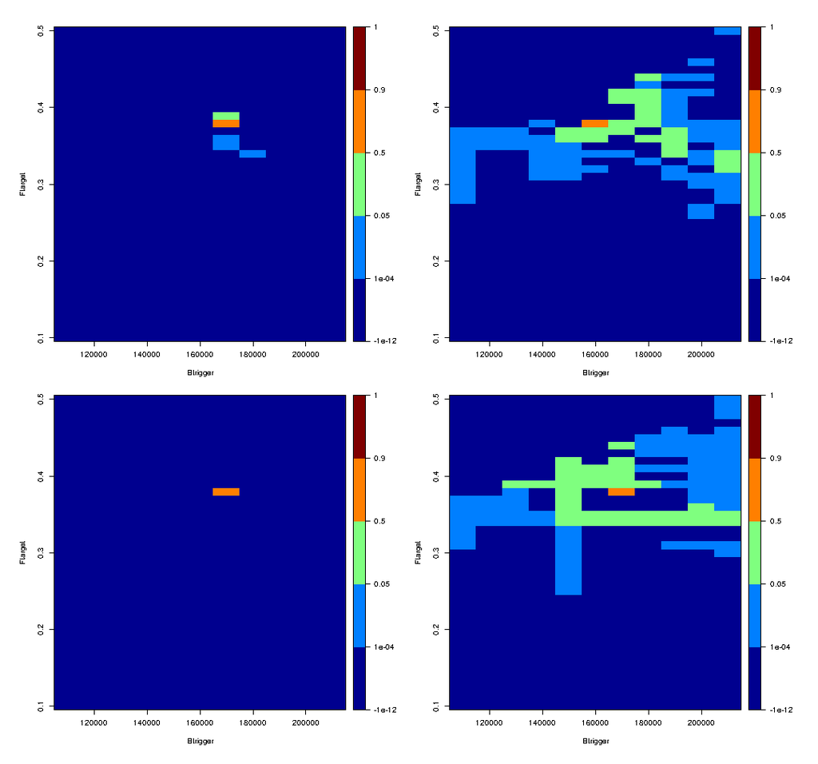

Figure 3: Comparison of convergence under different priors in the seventh round. In the top left, case_study8 with the mean of the GP set to zero only in the first round. In the top right, case_study8 with the mean of the GP set to zero in all rounds. In the bottom left, case_study8 augmented with the KG acquisition function with the mean of the GP set to zero in the first round only. In the bottom right, case_study8 augmented with the KG acquisition function with the mean of the GP set to zero in all rounds

## 3.5 Determining the best acquisition function

This was done to help us determine which acquisition function was most effective in our specific case as well as highlighting which acquisition function may be most effective in general, which could help us decide which will be most effective in the mixed fisheries context. However, the landscape of the objective function may be different in our mixed fisheries situation due to interactions between different stocks and particularly any choke stocks (Sun et al. 2023),(Pace 2024). This could mean that the acquisition function we choose for the single stock case may not be the most effective acquisition function in the mixed fisheries case (Shahriari et al. 2016). However, for now we will use the most effective function in a single–stock context in our mixed fisheries context.

We ran a timing test, a total evaluations test, a number of rounds test and a convergence test comparing the base method used in the Case Study in Spence (2025) to the base method augmented with the different acquisition functions we have mentioned above. The tests and their results can be seen through the links provided in Section 7.

Despite taking more time on average than the other methods in this case, the KG acquisition function method will be the best to use here because it requires less evaluations of the objective function and so is less expensive to run (Frazier 2018),(Jones, Schonlau, and Welch 1998),(Frazier, Powell, and Dayanik 2009). However, when sampling eight points per round it had the same number of rounds as the other methods for the Case Study. This is important because we evaluate the new points each round in parallel and so KG didn’t have the overwhelming lead in terms of computation time that would be expected for less evaluations (Shahriari et al. 2016). The results from the convergence test are essentially irrelevant for this comparison as all methods got the same result. Due to this decision, we will use KG as our preferred acquisition function throughout the mixed fisheries section of this report.

# 4 Applying the framework to a mixed fisheries context

## 4.1 Context

The aim of the second half of the project is to apply the methods from Section 3 to mixed fisheries. I use the methods from the first half of the project to but change the aim to finding the $F_{target}$ for each stock that is precautionary but maximises long-term catch. I set this goal because MixME is designed to run projections into the future, and looking at catch in the long term will minimise the chance that a simulation where a stock fails is chosen (Pace et al. 2025a),(Pace 2024),(ICES 2019a). We conduct 20 year projections into the future using the MixME package (Pace et al. 2025a). The 20 year projection from 2020-2039 follows guidelines from ICES to create long-term projections based on the biology of the stocks (ICES 2019a). We also follow ICES guidelines to only calculate catch and risk for the last ten years for long-term projection, to allow time for a recovery period (ICES 2019a).

I focused on the datasets from the Fixed fishing mortality management strategy example and the Exploring simulation outputs example which are both in the MixME documentation (Pace 2024). However, for the second dataset I was given a shortcut method by a researcher at Cefas which takes a more direct approach to the simulation. The code for these datasets is provided in Section 7. Both of these datasets have two stocks (cod and haddock) and two fleets (Pace 2024). This allows me to use the same methods as in the first half of the project by replacing $F_{target}$ with $F_{cod}$ and $B_{trigger}$ with $F_{had}$, where $F_{cod}$ and $F_{had}$ are the fishing mortalities for cod and haddock respectively. I was told by the same researcher at Cefas that the stocks are North Sea cod and Celtic Sea haddock, but using citations I can only back up that they are Atlantic cod and haddock (Pace 2024),(ICES, n.d.),(ICES, n.d.).

We create our new sample space to be a grid with all the combinations of $F_{cod}$ and $F_{had}$ both ranging from $0$ to $0.6$ in $0.02$ increments (Spence 2025). This range ensures that we are able to model stock collapse for cod by modelling values above $F_{lim}$ and that we can model stock recovery for cod by including very low values (ICES 2019c). It also allows us to model unsafe fishing for haddock by modelling values above $F_{MSY}$ (ICES 2019b). Recalling that cod is the choke stock for both of our datasets, this sample space is appropriate (Pace 2024),(Sun et al. 2023),(ICES 2019a).

For this half of the project, we have switched to modelling SSB directly instead of calculating the risk. This is due to the simulation being deterministic as both datasets only have one iteration and the noise for this is pre-calculated (Pace et al. 2025b). These conditions simplify the simulation but mean that we cannot use the standard ICES definition of risk (Pace et al. 2025b),(ICES 2019a). Instead, we adopt another process explained in Section 4.2. We claim that this method satisfies the ICES precautionary standard (ICES 2019a).

Due to the change in stocks being modelled, I have decided to keep the GP prior for catch modelled as the same form as in Equation 10. Despite the more complicated prior used in later rounds for the catch GP in Spence (2025) being designed to approximate yield curves, it may not be appropriate in a mixed fisheries context where the catch of one species is affected by the catch of another (Spence 2025),(Pace et al. 2025a),(Ulrich et al. 2012). Leaving the GP more general avoids mis-specification, ensuring that the GP can be appropriately fitted to the points (Williams and Rasmussen 2006).

The process for the first half of the project adapted to our new situation is outlined below. Firslty, note that we are now seeking to maximise the objective function below:

$$\small
g(\theta) = I_{[Cod\ B_{lim},\infty]}P(SSB_{Cod}<B_{lim}) \times I_{[Haddock\ B_{lim},\infty]}P(SSB_{Haddock}<B_{lim}) \times C(\theta)
\tag{13}$$

where the indicator functions are defined as beforehand, except using these new sets. $Cod\ B_{lim}$ and $Haddock\ B_{lim}$ are the $B_{lim}$ for cod and haddock respectively and $SSB_{Cod}$ and $SSB_{Haddock}$ are the $SSB$ for cod and haddock respectively. This follows on intuitively from the Equation 8 once we consider that we are now modelling for multiple stocks and want to maximise the catch whilst keeping both stocks safe.

## 4.2 Calculating the risk

MixME defines risk as the proportion of iterations in each year where $SSB$ falls below $B_{lim}$ (Pace 2024). However, due to only having one iteration in each of my datasets, I have experimented with using a different method to measure the risk (Pace 2024). In contrast to the first half of the project, we now calculate the risk using the $SSB$. Note that we also need the $B_{lim}$ for this method. We have a $B_{lim}$ for each stock, taken from ICES advice (ICES 2020b),(ICES 2020a). The $B_{lim}$ for cod is $107,000$ tonnes and the $B_{lim}$ for haddock is $9,227$ tonnes.

Throughout this section, we have assumed that the $SSB$ for each stock for each year outputted by the simulation is the true value. In reality there may be some uncertainty about this value and so we would need to take this into account (Pace et al. 2025a). This would still allow $\textrm{min}(SSB)$ to be modelled as a GP and the risk calculation to be the same so that the rest of the process can be carried out as above (as the KG acquisition function can handle noisy situations) (Frazier 2018). However, this is beyond the scope of my project and so I have not implemented this and will not discuss it in detail.

The GPs for $min(SSB)$ have remained modelled in the same way as risk from the first half of the project to avoid mis-specification (Williams and Rasmussen 2006),(Roustant, Ginsbourger, and Deville 2012b). They have also kept the same estimation method, nugget and kernel (Williams and Rasmussen 2006). ]. The $min(SSB)$ for each stock is not necessarily smooth. Due to our discrete time steps, overfishing or low recruitment can cause sudden drops. This means we need a kernel which can appropriately model these sudden drops seen in this real-world process. As justified in Section 3.4, the exponential kernel is appropriate for this. Maximum Likelihood Estimation is one of the standard methods used in the literature for our situation and our simulation is still deterministic and we still need our matrices to be invertible and so we keep the small nugget term (Roustant 2025),(Williams and Rasmussen 2006),(Frazier 2018).

Firstly, we extract the $\textrm{min}(SSB)$ for each stock from the result each of the simulations we have run (Pace 2024),(Pace et al. 2025a). We then put these results into the GPs we will use to model $\textrm{min}(SSB)$ for each stock. Next, we predict the $\textrm{min}(SSB)$ for every point in the sample space and calculate:

$$Risk = P(\textrm{min}(SSB) < B_{lim})$$

for each stock. This can be done using Equation 2. Then, we set the KG of any unsafe points to be zero so that they will not be chosen as points to be sampled in the future.

By ensuring that:

$$P(\textrm{min}(SSB) < B_{lim}) \le 0.05$$

we ensure that:

$$P(SSB < B_{lim}) \le 0.05
\tag{14}$$

for every year in the long term forecast. This guarantees that the maximum annual risk in this period remains below the 0.05 threshold, which is exactly what is required to meet the ICES precautionary standard due to their definition of $Prob3$ (ICES 2019a). This means that this risk calculation could be used in policy documents to set official catch limits in countries that have agreed to this standard (ICES 2019a).

## 4.3 The basics of the MixME model

### 4.3.1 Starting $F_{cod}$ and $F_{had}$

We started with $F_{cod} = 0.28$ and $F_{had} = 0.353$ based upon the values given in the Fixed fishing mortality management strategy example from the MixME wiki (Pace 2024). These were drawn from North Sea Cod and Celtic Sea Haddock advice (ICES 2021a),(ICES 2020b).

### 4.3.2 Creating the Operating model

We first create the operating model which contains the true data for the stocks and fleets in the dataset (Pace et al. 2025a). We have data for North Sea Cod from 1963-2019 and for Celtic Sea Haddock from 1993-2019 (Pace 2024). For the stocks, this includes the numbers, natural mortality, stock mean individual weight and proportion mature split by age and for fleets this includes landing numbers, landing mean individual weight, discard numbers, discard mean individual weight, selectivity and catchability (Pace 2024).

In both of our files, this is loaded with the dataset (Pace 2024). This true data is generated using standard age-structured equations to model the dynamics of the fleets and the stocks (Pace 2024). For every year, it has the catch (in terms of landings and discards) from each fleet and the survivors from that year (Pace 2024). It also contains a stock-recruitment model and recruitment is done at the beginning of each time step (Pace 2024). The steps for fully assembling the operating model for input into the MixME model are explained below.

#### 4.3.2.1 Estimate historic quota-share for the two fleets

Firstly, we use the operating model to determine the quota share of the catch for each fleet for each year in our projection. This is done by assuming in each fleet that the quota share for each stock corresponds to the proportion of landings of that stock by that fleet (Pace 2024).

#### 4.3.2.2 Project structures 20 years into the future

To carry out our 20 year projection, we need to extend the stock and fishery structures forward from 2019 into 2039. There are three categories of parameters that are not estimated dynamically and so need to be extended (Pace 2024). These are:

1. All stock parameters, landings and discards mean individual weights and landed fraction
2. Catchability and catch selection
3. Quota-share

We project the parameters in each of these categories from 2019-2039 using the average from the last three years (Pace 2024). This means we fill in the actual values we will use, instead of calculating a percentage that is then used in a further calculation like in the quota share section (Pace 2024).

#### 4.3.2.3 Calculate numbers of both stocks in initial year

To be able to do our projections of catch, we need to know the number of each stock in each age class at the beginning of the first projection year, 2020. This requires us to do a 1-year short term forecast from our starting point of 2019 using the FLasher package (Pace 2024). We set an arbitrary forecast target for this forecast (Pace 2024). This is because the forecast target is designed to tell the simulation what to aim for by the end of 2020, but we want the stock numbers at the beginning of 2020 and so this has no effect on the result we want (Pace 2024).

#### 4.3.2.4 Creating the Observation Error Model

This is another important component of the model (Pace 2024). We create the observation error model where we apply pre-sampled noise to the catch from each fleet (Pace 2024). We generate future stock and management advice from this object (Pace 2024).

### 4.3.3 Creating the input object, running the simulation and getting the results

We then use the operating model to make the MixME input object which we can use to run the simulation (Pace 2024). This is created from the operating model and the observation error model (Pace 2024). Then, we run the simulation. It is important to note that the $F_{cod}$ and $F_{had}$ we choose at the start remain constant throughout the simulation (Pace 2024).

The tracking object produced by the simulation contains the catch and the $SSB$ from each year of the simulation, which is how we have been extracting these throughout this document (Pace 2024). It also contains simulation performance and diagnostics statistics (Pace 2024). We can check for management advice failure, effort optimisation failure and the message given if there was any failure (Pace 2024). Effort optimisation failure can be used to see if we are over-fishing the stocks to a point that they will go extinct (Pace 2024). Other results we can see are the over-quota catches and the quota uptake (Pace 2024). Lastly, we can check which stock is the choke stock (Pace 2024).

### 4.3.4 Additions or Differences in the Shortcut Model

We use the same data as in the Exploring simulation outputs example from the wiki (Pace 2024). There are some small differences in how we calculate the HCR and do our one-year forecasts in the shortcut model. However, this is not yet up on the wiki and so we will not be describing it in detail (Pace 2024).

## 4.4 Parallelisation

This process has been set up so that it is easy to run in parallel. We are able to load the dataset we need once and then run the simulations for each point we have chosen to sample in the round in parallel. As they run, each process only gathers the values we need and removes the rest of the results of the simulation to save memory. Here, the values we need are the $min(SSB)$ for cod, the $min(SSB)$ for haddock and the total catch of cod and haddock over the years 2030-2039. Then, we collect these results and set up the GPs for each of them. After this, we run through the process of removing any implausible points and selecting the points to sample in the next round in a very similar way to the first half of this project (Spence 2025). We iterate this process until the optimal point(s) are found.

# 5 Analysis of Results

The convergence tests I ran after augmenting the original method in Spence (2025) with different acquisition functions confirmed that my method still led to convergence to the correct point identified in the paper for every acquisition function. The convergence tests can be found in the code in Section 7.

From running our simulation for the shortcut model from the second half of the project on the Viking HPC, we were able to obtain some results (York, n.d.). The shortcut model initially gave us a long list of parameters, each with $F_{cod} = 0.42$ and $F_{had} \ge 0.34$. As $F_{had} = 0.34$ was given as an optimal parameter in the list, it means that this results in the same long-term catch of haddock as if we were to fish at any $F_{had} > 0.34$, as we were maximising the total long-term catch. Remembering that cod is the choke stock, this list also suggests that when we fish at $F_{cod} = 0.42$ this causes us to fish at $F_{had} = 0.34$ due to the ratio of cod to haddock that we are catching across the fleets (Pace 2024). Thus, $F_{cod} = 0.42$ and $F_{had} = 0.34$ are the optimal parameters suggested by the shortcut simulation.

These appear to be relatively high. ICES documents regularly suggest lower values for $F_{cod}$ in the North Sea region for their $F_{MSY}$ values (ICES 2019c),(ICES 2020a). Looking at the most recent advice, the model’s output of $F_{cod}=0.42$ is significantly above the $F_{MSY} = 0.231$ but below $F_{PA} = 0.464$ (ICES 2025b). This value aligns with my risk calculation by being below $F_{PA}$, as this ensures that Equation 14 holds in the long-term (ICES 2021b). However, I would have expected my value to be closer to $F_{MSY}$ as this again ensures Equation 14 but is maximising the long-term catch (ICES 2021b).

On the other hand, for Celtic Sea haddock the optimal parameter given by the shortcut model $F_{had} = 0.34$ is below the $F_{MSY} = 0.353$ and the $F_{PA} = 0.708$ given in the latest advice and sits in a similar area historically (ICES 2025a),(ICES 2019b),(ICES 2020b). This shows that the shortcut model has produced a safe value for $F_{had}$ for Celtic Sea haddock according to the latest ICES guidelines.

The discrepancy in the $F_{cod}$ given by the shortcut model and those suggested by ICES (2025b) could be due to ICES maximising the long-term single-stock catch for cod whilst my simulation aims to maximise the long-term total catch for both cod and haddock (Sun et al. 2023). This could lead to the quota for cod being raised, whilst remaining precautionary, so that we can fish more haddock. Allowing this could result in a lower long-term catch for cod, but this reduction in cod catch could be made up for by the increase in haddock catch. Thus, the model may be trying to balance the trade off of reducing the long term catch of cod by fishing above the $F_{MSY}$ for cod with catching more haddock if it does this (Pace et al. 2025a),(Sun et al. 2023). This would result in a value between $F_{MSY}$ and $F_{PA}$ for cod which is exactly what we see above.

# 6 Conclusion and Further areas for Development

Overall, this framework presents a more computationally efficient way for stakeholders to be able determine management strategies that will keep stocks healthy whilst maximising the long-term catch of the fishery (ICES 2019a). This is especially relevant at this time because many mixed fisheries are struggling after the collapse of an individual stock causes them to have to severely limit catch of others despite growing demand from consumers (ICES 2025c),(ICES 2025d),(United Nations. Fisheries Department 2024). By reducing computation time for MSE grid searches, we make it easier for more simulations to be run, which could allow fisheries advice to be published in a more timely manner (Spence 2025),(Jones, Schonlau, and Welch 1998). This could allow organisations such as ICES to be able to keep pace with the changes in environment and in interactions between species (Holsman et al. 2019). As a result, fisheries advice could be more accurate and relevant, contributing towards a healthier ecosystem and planet.

# 7 Appendix

The code is all contained in the DissertationWork repository on Github (Bowen 2026).

The visualisations of the GPs from the first half of the project can be seen in Gaussian Process Visualisation and Experimentation folder in the `case_study8_3D.qmd` file.

The test for which acquisition function is bets can be seen as the most recent tests in the “Actions” tab or can be seen in the Documents folder in the Deciding which acquisition function is best based on results from tests pdf.

The original MixME scripts can be found in the /MixME_experimentation/Original scripts folder.

## References

Azimi, Javad, Alan Fern, and Xiaoli Fern. 2010. “Batch Bayesian Optimization via Simulation Matching.” In *Advances in Neural Information Processing Systems*, edited by J. Lafferty, C. Williams, J. Shawe-Taylor, R. Zemel, and A. Culotta. Vol. 23. Curran Associates, Inc. https://proceedings.neurips.cc/paper_files/paper/2010/file/e702e51da2c0f5be4dd354bb3e295d37-Paper.pdf.

Bowen, Emma. 2026. “DissertationWork Repository.” https://github.com/dtj504-pixel/DissertationWork.

Frazier, Peter. 2018. “A Tutorial on Bayesian Optimization.” https://doi.org/10.48550/arXiv.1807.02811.

Frazier, Peter, Warren Powell, and Savas Dayanik. 2009. “The Knowledge-Gradient Policy for Correlated Normal Beliefs.” *INFORMS Journal on Computing* 21 (4): 599–613.

Hartigan, J. A., and M. A. Wong. 1979. “A k-Means Clustering Algorithm.” *Journal of the Royal Statistical Society Series C: Applied Statistics* 28 (1): 100–108. https://doi.org/10.2307/2346830.

Hofert, Marius, and Martin Mächler. 2016. “Parallel and Other Simulations in r Made Easy: An End-to-End Study.” *Journal of Statistical Software* 69 (4): 1–44. https://doi.org/10.18637/jss.v069.i04.

Holsman, KK, Elliott Hazen, A. Haynie, Sophie Gourguet, Anne Hollowed, Steven Bograd, Jameal Samhouri, and Kerim Aydin. 2019. “Towards Climate Resiliency in Fisheries Management.” *ICES Journal of Marine Science* 76 (March). https://doi.org/10.1093/icesjms/fsz031.

Huang, D., Theodore Allen, William Notz, and Ning Zheng. 2006. “Global Optimization of Stochastic BlackBox Systems via Sequential Kriging Meta-Models.” *Journal of Global Optimization* 34: 441–66. https://doi.org/10.1007/s10898-005-2454-3.

ICES. 2019a. “Workshop on Guidelines for Management Strategy Evaluations (WKGMSE2),” January. https://doi.org/10.17895/ices.pub.5531.

———. 2019b. “Haddock (Melanogrammus aeglefinus) in divisions 7.b–k (southern Celtic Seas and English Channel),” June. https://doi.org/10.17895/ices.advice.4785.

———. 2019c. “Cod (Gadus morhua) in Subarea 4, Division 7.d, and Subdivision 20 (North Sea, eastern English Channel, Skagerrak),” November. https://doi.org/10.17895/ices.advice.5640.

———. 2020a. “Cod (Gadus morhua) in Subarea 4, Division 7.d, and Subdivision 20 (North Sea, eastern English Channel, Skagerrak),” June. https://doi.org/10.17895/ices.advice.5891.

———. 2020b. “Haddock (Melanogrammus aeglefinus) in divisions 7.b–k (southern Celtic Seas and English Channel),” October. https://doi.org/10.17895/ices.advice.5897.

———. 2021a. “Benchmark Workshop on North Sea Stocks (WKNSEA),” April. https://doi.org/10.17895/ices.pub.7922.

———. 2021b. “Advice on fishing opportunities (2021),” July. https://doi.org/10.17895/ices.advice.7720.

———. 2025a. “Haddock (Melanogrammus aeglefinus) in Divisions 7.b-k (southern Celtic Seas and English Channel),” June. https://doi.org/10.17895/ices.advice.27202608.v1.

———. 2025b. “Cod (Gadus morhua) in Subarea 4, divisions 6.a and 7.d, and Subdivision 20 (North Sea, West of Scotland, eastern English Channel and Skagerrak),” September. https://doi.org/10.17895/ices.advice.27202566.v1.

———. 2025c. “Celtic Sea mixed-fisheries considerations,” November. https://doi.org/10.17895/ices.advice.30374749.v1.

———. 2025d. “Greater North Sea mixed-fisheries considerations,” November. https://doi.org/10.17895/ices.advice.30316027.v1.

———. n.d. “ICES-FishMap Cod.” https://www.ices.dk/about-ICES/projects/EU-RFP/EU%20Repository/ICES%20FIshMap/ICES%20FishMap%20species%20factsheet-cod.pdf.

Jones, Donald, Matthias Schonlau, and William Welch. 1998. “Efficient Global Optimization of Expensive Black-Box Functions.” *Journal of Global Optimization* 13: 455–92. https://doi.org/10.1023/A:1008306431147.

Kodinariya, Trupti M, Prashant R Makwana, et al. 2013. “Review on Determining Number of Cluster in k-Means Clustering.” *International Journal* 1 (6): 90–95.

Letham, Benjamin, Brian Karrer, Guilherme Ottoni, and Eytan Bakshy. 2018. “Constrained Bayesian Optimization with Noisy Experiments.” https://arxiv.org/abs/1706.07094.

Pace, Matthew. 2024. “MixME Wiki.” https://github.com/CefasRepRes/MixME/wiki.

Pace, Matthew, José Oliveira, Simon Fischer, and Paul Dolder. 2025a. “MixME: An r Package to Simulation‐test Fisheries Management Robustness to Mixed‐fisheries Interactions.” *Methods in Ecology and Evolution* 16 (February): 698–706. https://doi.org/10.1111/2041-210X.70005.

———. 2025b. “"Supplementary Material a: Conditioning a Multi-Stock, Multi-Fleet Operating Model for Celtic Sea Cod, Haddock and Whiting",” February. https://besjournals.onlinelibrary.wiley.com/action/downloadSupplement?doi=10.1111%2F2041-210X.70005&file=mee370005-sup-0001-Supinfo1.pdf.

RDocumentation. 2025. https://www.rdocumentation.org/packages/stats/versions/3.6.2/topics/kmeans.

Roustant, Olivier. 2025. https://www.rdocumentation.org/packages/DiceKriging/versions/1.6.1.

Roustant, Olivier, David Ginsbourger, and Yves Deville. 2012a. “DiceKriging, DiceOptim: Two r Packages for the Analysis of Computer Experiments by Kriging-Based Metamodeling and Optimization.” *Journal of Statistical Software* 51 (1): 1–55. https://doi.org/10.18637/jss.v051.i01.

———. 2012b. “DiceKriging, DiceOptim: Two r Packages for the Analysis of Computer Experiments by Kriging-Based Metamodeling and Optimization.” *Journal of Statistical Software* 51 (1): 1–55. https://doi.org/10.18637/jss.v051.i01.

Shahriari, Bobak, Kevin Swersky, Ziyu Wang, Ryan P. Adams, and Nando de Freitas. 2016. “Taking the Human Out of the Loop: A Review of Bayesian Optimization.” *Proceedings of the IEEE* 104 (1): 148–75. https://doi.org/10.1109/JPROC.2015.2494218.

Spence, Michael A. 2025. “Using History Matching to Speed up Management Strategy Evaluation Grid Searches.” *Canadian Journal of Fisheries and Aquatic Sciences* 82: 1–14. https://doi.org/10.1139/cjfas-2024-0191.

Sun, Ming, Yunzhou Li, Lisa Suatoni, Alexander Kempf, Marc Taylor, Elizabeth Fulton, Cody Szuwalski, Maria Teresa Spedicato, and Yong Chen. 2023. “Status and Management of Mixed Fisheries: A Global Synthesis.” *Reviews in Fisheries Science & Aquaculture* 31 (4): 458–82. https://doi.org/10.1080/23308249.2023.2213769.

Trusts, The Pew Charitable. 2016. “Harvest Control Rules Approaches to Effective Long-Term Fisheries Management,” July. https://www.pew.org/en/research-and-analysis/fact-sheets/2016/07/harvest-control-rules.

———. 2019. “Harvest Strategies: 21st Century Fisheries Management Well-Designed Systems Can Ensure Long-Term Health of Fisheries.” https://www.pew.org/en/research-and-analysis/issue-briefs/2019/11/harvest-strategies-21st-century-fisheries-management.

Ulrich, Clara, Douglas C. K. Wilson, J. Rasmus Nielsen, Francois Bastardie, Stuart A. Reeves, Bo S. Andersen, and Ole R. Eigaard. 2012. “Challenges and Opportunities for Fleet- and Métier-Based Approaches for Fisheries Management Under the European Common Fishery Policy.” *Ocean & Coastal Management* 70: 38–47. https://doi.org/https://doi.org/10.1016/j.ocecoaman.2012.06.002.

Ungredda, Juan, Michael Pearce, and Juergen Branke. 2022. “Efficient Computation of the Knowledge Gradient for Bayesian Optimization.” https://arxiv.org/abs/2209.15367.

United Nations. Fisheries Department, Agriculture Organization of the. 2024. *The State of World Fisheries and Aquaculture 2024 – Blue Transformation in Action*. Food; Agriculture Organization of the United Nations. https://doi.org/10.4060/cd0683en.

Williams, Christopher KI, and Carl Edward Rasmussen. 2006. *Gaussian Processes for Machine Learning*. Vol. 2. 3. MIT press Cambridge, MA.

York, University of. n.d. “Viking Documentation.” https://vikingdocs.york.ac.uk/index.html.